# TABULAR PLAYGROUND - JULY 2021- EXPLORATORY ANALYSIS OF AIR POLLUTANTS WITH REGRESSION MODELS

### This notebook is used for learning purposes. The data is partially from real world and partially artificially generated. Data link [here](https://www.kaggle.com/c/tabular-playground-series-jul-2021).

The challenge is to predict the values of air pollution measurements over time, based on basic weather information (temperature and humidity) and the input values of 5 sensors.

#### Predictors:

deg_c = temperature

relative_humidity = humidity

absolute_humidity = normalized humidity

sensors 1 to 5 = sensor data

#### Targets:

target_carbon_monoxide = CO values in air

target_benze = beneze values in air

target_nitrogen_oxides = NO values in air

# 1. Loading and Understanding Data

```python
import pandas as pd  #data manipulation
import numpy as np   #linear algebra
import matplotlib.pyplot as plt   #plotting library
import seaborn as sns       #plotting library

#load data
train = pd.read_csv('../input/tabular-playground-series-jul-2021/train.csv')
test_unseen = pd.read_csv('../input/tabular-playground-series-jul-2021/test.csv')
```

```python
train.head()
```

|  | date_time | deg_C | relative_humidity | absolute_humidity | sensor_1 | sensor_2 | sensor_3 | sensor_4 | sensor_5 | target_carbon_monoxide | target_benzene | target_nitrogen_oxides |
| --- | --- | --- | --- | --- | --- | --- | --- | --- | --- | --- | --- | --- |
| 0 | 2010-03-10 18:00:00 | 13.1 | 46.0 | 0.7578 | 1387.2 | 1087.8 | 1056.0 | 1742.8 | 1293.4 | 2.5 | 12.0 | 167.7 |
| 1 | 2010-03-10 19:00:00 | 13.2 | 45.3 | 0.7255 | 1279.1 | 888.2 | 1197.5 | 1449.9 | 1010.9 | 2.1 | 9.9 | 98.9 |
| 2 | 2010-03-10 20:00:00 | 12.6 | 56.2 | 0.7502 | 1331.9 | 929.6 | 1060.2 | 1586.1 | 1117.0 | 2.2 | 9.2 | 127.1 |
| 3 | 2010-03-10 21:00:00 | 11.0 | 62.4 | 0.7867 | 1321.0 | 929.0 | 1102.9 | 1536.5 | 1263.2 | 2.2 | 9.7 | 177.2 |
| 4 | 2010-03-10 22:00:00 | 11.9 | 59.0 | 0.7888 | 1272.0 | 852.7 | 1180.9 | 1415.5 | 1132.2 | 1.5 | 6.4 | 121.8 |

```python
train.info()
```

```
<class 'pandas.core.frame.DataFrame'>
RangeIndex: 7111 entries, 0 to 7110
Data columns (total 12 columns):
 #   Column                  Non-Null Count  Dtype
---  ------                  --------------  -----
 0   date_time               7111 non-null   object
 1   deg_C                   7111 non-null   float64
 2   relative_humidity       7111 non-null   float64
 3   absolute_humidity       7111 non-null   float64
 4   sensor_1                7111 non-null   float64
 5   sensor_2                7111 non-null   float64
 6   sensor_3                7111 non-null   float64
 7   sensor_4                7111 non-null   float64
 8   sensor_5                7111 non-null   float64
 9   target_carbon_monoxide  7111 non-null   float64
 10  target_benzene          7111 non-null   float64
 11  target_nitrogen_oxides  7111 non-null   float64
dtypes: float64(11), object(1)
memory usage: 666.8+ KB
```

```python
train[1:].describe() #check the descriptions of the data without the object column
```

|  | deg_C | relative_humidity | absolute_humidity | sensor_1 | sensor_2 | sensor_3 | sensor_4 | sensor_5 | target_carbon_monoxide | target_benzene | target_nitrogen_oxides |
| --- | --- | --- | --- | --- | --- | --- | --- | --- | --- | --- | --- |
| count | 7110.000000 | 7110.000000 | 7110.000000 | 7110.000000 | 7110.000000 | 7110.00000 | 7110.000000 | 7110.000000 | 7110.000000 | 7110.000000 | 7110.000000 |
| mean | 20.879128 | 47.561224 | 1.110358 | 1091.530520 | 938.043910 | 883.87910 | 1513.206062 | 998.294065 | 2.086160 | 10.236835 | 204.071899 |
| std | 7.937939 | 17.399945 | 0.398956 | 218.524793 | 281.993227 | 310.47148 | 350.194353 | 381.548478 | 1.447203 | 7.694938 | 193.940883 |
| min | 1.300000 | 8.900000 | 0.198800 | 620.300000 | 364.000000 | 310.60000 | 552.900000 | 242.700000 | 0.100000 | 0.100000 | 1.900000 |
| 25% | 14.900000 | 33.700000 | 0.855925 | 930.225000 | 734.800000 | 681.02500 | 1320.275000 | 722.825000 | 1.000000 | 4.500000 | 76.425000 |
| 50% | 20.700000 | 47.300000 | 1.083550 | 1060.450000 | 914.200000 | 827.80000 | 1513.100000 | 928.650000 | 1.700000 | 8.500000 | 141.000000 |
| 75% | 25.800000 | 60.800000 | 1.404175 | 1215.800000 | 1124.100000 | 1008.62500 | 1720.350000 | 1224.600000 | 2.800000 | 14.200000 | 260.000000 |
| max | 46.100000 | 90.800000 | 2.231000 | 2088.300000 | 2302.600000 | 2567.40000 | 2913.800000 | 2594.600000 | 12.500000 | 63.700000 | 1472.300000 |

```python
train.isnull().values.any() #check null values
```

```
False
```

### Thoughts:

1. The data is relatively clean. Only one object column ie. datetime. Can be engineerd with one hot encoding. No other discrete columns can proceed further.
2. std for sensor columns are very high. Should be engineered

```python
total = [train,test_useen]  #merging train and test into single dataframe
total = pd.concat(total)
total
```

|  | date_time | deg_C | relative_humidity | absolute_humidity | sensor_1 | sensor_2 | sensor_3 | sensor_4 | sensor_5 | target_carbon_monoxide | target_benzene | target_nitrogen_oxides |
| --- | --- | --- | --- | --- | --- | --- | --- | --- | --- | --- | --- | --- |
| 0 | 2010-03-10 18:00:00 | 13.1 | 46.0 | 0.7578 | 1387.2 | 1087.8 | 1056.0 | 1742.8 | 1293.4 | 2.5 | 12.0 | 167.7 |
| 1 | 2010-03-10 19:00:00 | 13.2 | 45.3 | 0.7255 | 1279.1 | 888.2 | 1197.5 | 1449.9 | 1010.9 | 2.1 | 9.9 | 98.9 |
| 2 | 2010-03-10 20:00:00 | 12.6 | 56.2 | 0.7502 | 1331.9 | 929.6 | 1060.2 | 1586.1 | 1117.0 | 2.2 | 9.2 | 127.1 |
| 3 | 2010-03-10 21:00:00 | 11.0 | 62.4 | 0.7867 | 1321.0 | 929.0 | 1102.9 | 1536.5 | 1263.2 | 2.2 | 9.7 | 177.2 |
| 4 | 2010-03-10 22:00:00 | 11.9 | 59.0 | 0.7888 | 1272.0 | 852.7 | 1180.9 | 1415.5 | 1132.2 | 1.5 | 6.4 | 121.8 |
| ... | ... | ... | ... | ... | ... | ... | ... | ... | ... | ... | ... | ... |
| 2242 | 2011-04-04 10:00:00 | 23.2 | 28.7 | 0.7568 | 1340.3 | 1023.9 | 522.8 | 1374.0 | 1659.8 | NaN | NaN | NaN |
| 2243 | 2011-04-04 11:00:00 | 24.5 | 22.5 | 0.7119 | 1232.8 | 955.1 | 616.1 | 1226.1 | 1269.0 | NaN | NaN | NaN |
| 2244 | 2011-04-04 12:00:00 | 26.6 | 19.0 | 0.6406 | 1187.7 | 1052.4 | 572.8 | 1253.4 | 1081.1 | NaN | NaN | NaN |
| 2245 | 2011-04-04 13:00:00 | 29.1 | 12.7 | 0.5139 | 1053.2 | 1009.0 | 702.0 | 1009.8 | 808.5 | NaN | NaN | NaN |
| 2246 | 2011-04-04 14:00:00 | 27.9 | 13.5 | 0.5028 | 1124.6 | 1078.4 | 608.2 | 1061.3 | 816.0 | NaN | NaN | NaN |

9358 rows × 12 columns

### Feature engineer the datetime column

extracting months, day of the month, hours, day name, time of the day and weekend or weekday check

```python
'''
months and day of the months
'''

total.date_time = pd.to_datetime(total.date_time)
months = total.date_time.dt.month
monthly_days = total.date_time.dt.day
hours = total.date_time.dt.hour
day_name = total.date_time.dt.day_name()
days = pd.get_dummies(day_name)
days
```

|  | Friday | Monday | Saturday | Sunday | Thursday | Tuesday | Wednesday |
| --- | --- | --- | --- | --- | --- | --- | --- |
| 0 | 0 | 0 | 0 | 0 | 0 | 0 | 1 |
| 1 | 0 | 0 | 0 | 0 | 0 | 0 | 1 |
| 2 | 0 | 0 | 0 | 0 | 0 | 0 | 1 |
| 3 | 0 | 0 | 0 | 0 | 0 | 0 | 1 |
| 4 | 0 | 0 | 0 | 0 | 0 | 0 | 1 |
| ... | ... | ... | ... | ... | ... | ... | ... |
| 2242 | 0 | 1 | 0 | 0 | 0 | 0 | 0 |
| 2243 | 0 | 1 | 0 | 0 | 0 | 0 | 0 |
| 2244 | 0 | 1 | 0 | 0 | 0 | 0 | 0 |
| 2245 | 0 | 1 | 0 | 0 | 0 | 0 | 0 |
| 2246 | 0 | 1 | 0 | 0 | 0 | 0 | 0 |

9358 rows × 7 columns

```python
'''
part of the days, seperating into 5 parts based on daylight and one hot enconding the resultant
categorical values
'''

def daypart(hour):
    if hour in [2,3,4,5]:
        return "dawn"
    elif hour in [6,7,8,9]:
        return "morning"
    elif hour in [10,11,12,13]:
        return "noon"
    elif hour in [14,15,16,17]:
        return "afternoon"
    elif hour in [18,19,20,21]:
        return "evening"
    else: return "midnight"

raw_days = hours.apply(daypart)
dayparts = pd.get_dummies(raw_days)
dayparts = dayparts[['dawn','morning','noon','afternoon','evening','midnight']]
dayparts
```

|  | dawn | morning | noon | afternoon | evening | midnight |
| --- | --- | --- | --- | --- | --- | --- |
| 0 | 0 | 0 | 0 | 0 | 1 | 0 |
| 1 | 0 | 0 | 0 | 0 | 1 | 0 |
| 2 | 0 | 0 | 0 | 0 | 1 | 0 |
| 3 | 0 | 0 | 0 | 0 | 1 | 0 |
| 4 | 0 | 0 | 0 | 0 | 0 | 1 |
| ... | ... | ... | ... | ... | ... | ... |
| 2242 | 0 | 0 | 1 | 0 | 0 | 0 |
| 2243 | 0 | 0 | 1 | 0 | 0 | 0 |
| 2244 | 0 | 0 | 1 | 0 | 0 | 0 |
| 2245 | 0 | 0 | 1 | 0 | 0 | 0 |
| 2246 | 0 | 0 | 0 | 1 | 0 | 0 |

9358 rows × 6 columns

```python
'''
check if the day is a weekend or otherwise
'''
is_weekend = day_name.apply(lambda x : 1 if x in ['Saturday','Sunday'] else 0)
is_weekend = pd.DataFrame({'is_weekend':is_weekend})
```

```python
'''
concat the resultant columns and split the train and test df back based on the original index
'''

final = pd.concat([total, dayparts, days,is_weekend],axis=1)
final = final.drop('date_time',axis=1)
train_eng = final[:7111]
test_eng = final.iloc[7112:,:]

print(f'train :{train_eng.shape}, test: {test_eng.shape}')
```

```
train :(7111, 25), test: (2246, 25)
```

```python
train_eng
```

|  | deg_C | relative_humidity | absolute_humidity | sensor_1 | sensor_2 | sensor_3 | sensor_4 | sensor_5 | target_carbon_monoxide | target_benzene | ... | evening | midnight | Friday | Monday | Saturday | Sunday | Thursday | Tuesday | Wednesday | is_weekend |
| --- | --- | --- | --- | --- | --- | --- | --- | --- | --- | --- | --- | --- | --- | --- | --- | --- | --- | --- | --- | --- | --- |
| 0 | 13.1 | 46.0 | 0.7578 | 1387.2 | 1087.8 | 1056.0 | 1742.8 | 1293.4 | 2.5 | 12.0 | ... | 1 | 0 | 0 | 0 | 0 | 0 | 0 | 0 | 1 | 0 |
| 1 | 13.2 | 45.3 | 0.7255 | 1279.1 | 888.2 | 1197.5 | 1449.9 | 1010.9 | 2.1 | 9.9 | ... | 1 | 0 | 0 | 0 | 0 | 0 | 0 | 0 | 1 | 0 |
| 2 | 12.6 | 56.2 | 0.7502 | 1331.9 | 929.6 | 1060.2 | 1586.1 | 1117.0 | 2.2 | 9.2 | ... | 1 | 0 | 0 | 0 | 0 | 0 | 0 | 0 | 1 | 0 |
| 3 | 11.0 | 62.4 | 0.7867 | 1321.0 | 929.0 | 1102.9 | 1536.5 | 1263.2 | 2.2 | 9.7 | ... | 1 | 0 | 0 | 0 | 0 | 0 | 0 | 0 | 1 | 0 |
| 4 | 11.9 | 59.0 | 0.7888 | 1272.0 | 852.7 | 1180.9 | 1415.5 | 1132.2 | 1.5 | 6.4 | ... | 0 | 1 | 0 | 0 | 0 | 0 | 0 | 0 | 1 | 0 |
| ... | ... | ... | ... | ... | ... | ... | ... | ... | ... | ... | ... | ... | ... | ... | ... | ... | ... | ... | ... | ... | ... |
| 7106 | 9.2 | 32.0 | 0.3871 | 1000.5 | 811.2 | 873.0 | 909.0 | 910.5 | 1.3 | 5.1 | ... | 1 | 0 | 1 | 0 | 0 | 0 | 0 | 0 | 0 | 0 |
| 7107 | 9.1 | 33.2 | 0.3766 | 1022.7 | 790.0 | 951.6 | 912.9 | 903.4 | 1.4 | 5.8 | ... | 1 | 0 | 1 | 0 | 0 | 0 | 0 | 0 | 0 | 0 |
| 7108 | 9.6 | 34.6 | 0.4310 | 1044.4 | 767.3 | 861.9 | 889.2 | 1159.1 | 1.6 | 5.2 | ... | 0 | 1 | 1 | 0 | 0 | 0 | 0 | 0 | 0 | 0 |
| 7109 | 8.0 | 40.7 | 0.4085 | 952.8 | 691.9 | 908.5 | 917.0 | 1206.3 | 1.5 | 4.6 | ... | 0 | 1 | 1 | 0 | 0 | 0 | 0 | 0 | 0 | 0 |
| 7110 | 8.0 | 41.3 | 0.4375 | 1108.8 | 745.7 | 797.1 | 880.0 | 1273.1 | 1.4 | 4.1 | ... | 0 | 1 | 0 | 0 | 1 | 0 | 0 | 0 | 0 | 1 |

7111 rows × 25 columns

```python
test_eng
```

|  | deg_C | relative_humidity | absolute_humidity | sensor_1 | sensor_2 | sensor_3 | sensor_4 | sensor_5 | target_carbon_monoxide | target_benzene | ... | evening | midnight | Friday | Monday | Saturday | Sunday | Thursday | Tuesday | Wednesday | is_weekend |
| --- | --- | --- | --- | --- | --- | --- | --- | --- | --- | --- | --- | --- | --- | --- | --- | --- | --- | --- | --- | --- | --- |
| 1 | 5.1 | 51.7 | 0.4564 | 1249.5 | 864.9 | 687.9 | 972.8 | 1714.0 | NaN | NaN | ... | 0 | 1 | 0 | 0 | 1 | 0 | 0 | 0 | 0 | 1 |
| 2 | 5.8 | 51.5 | 0.4689 | 1102.6 | 878.0 | 693.7 | 941.9 | 1300.8 | NaN | NaN | ... | 0 | 0 | 0 | 0 | 1 | 0 | 0 | 0 | 0 | 1 |
| 3 | 5.0 | 52.3 | 0.4693 | 1139.7 | 916.2 | 725.6 | 1011.0 | 1283.0 | NaN | NaN | ... | 0 | 0 | 0 | 0 | 1 | 0 | 0 | 0 | 0 | 1 |
| 4 | 4.5 | 57.5 | 0.4650 | 1022.4 | 838.5 | 871.5 | 967.0 | 1142.3 | NaN | NaN | ... | 0 | 0 | 0 | 0 | 1 | 0 | 0 | 0 | 0 | 1 |
| 5 | 4.5 | 53.7 | 0.4759 | 1004.0 | 745.5 | 914.2 | 989.1 | 973.8 | NaN | NaN | ... | 0 | 0 | 0 | 0 | 1 | 0 | 0 | 0 | 0 | 1 |
| ... | ... | ... | ... | ... | ... | ... | ... | ... | ... | ... | ... | ... | ... | ... | ... | ... | ... | ... | ... | ... | ... |
| 2242 | 23.2 | 28.7 | 0.7568 | 1340.3 | 1023.9 | 522.8 | 1374.0 | 1659.8 | NaN | NaN | ... | 0 | 0 | 0 | 1 | 0 | 0 | 0 | 0 | 0 | 0 |
| 2243 | 24.5 | 22.5 | 0.7119 | 1232.8 | 955.1 | 616.1 | 1226.1 | 1269.0 | NaN | NaN | ... | 0 | 0 | 0 | 1 | 0 | 0 | 0 | 0 | 0 | 0 |
| 2244 | 26.6 | 19.0 | 0.6406 | 1187.7 | 1052.4 | 572.8 | 1253.4 | 1081.1 | NaN | NaN | ... | 0 | 0 | 0 | 1 | 0 | 0 | 0 | 0 | 0 | 0 |
| 2245 | 29.1 | 12.7 | 0.5139 | 1053.2 | 1009.0 | 702.0 | 1009.8 | 808.5 | NaN | NaN | ... | 0 | 0 | 0 | 1 | 0 | 0 | 0 | 0 | 0 | 0 |
| 2246 | 27.9 | 13.5 | 0.5028 | 1124.6 | 1078.4 | 608.2 | 1061.3 | 816.0 | NaN | NaN | ... | 0 | 0 | 0 | 1 | 0 | 0 | 0 | 0 | 0 | 0 |

2246 rows × 25 columns

Okay, now we have 25 columns that we feature engineered. But still we need to look into the distributions of the other predictor variables before training the models.

# 2. Data Distributions

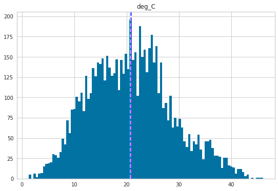

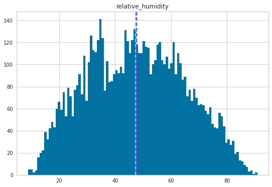

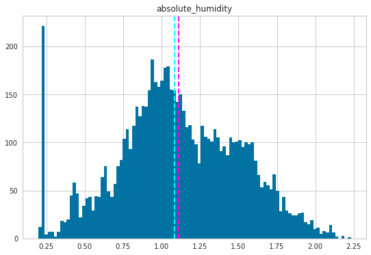

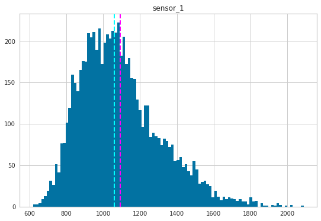

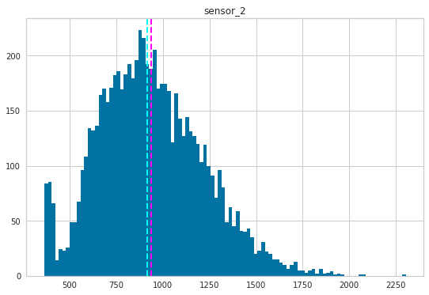

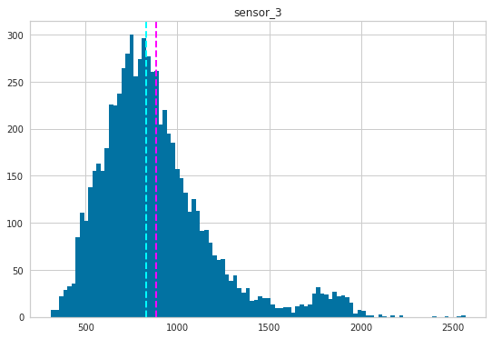

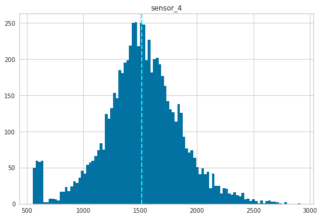

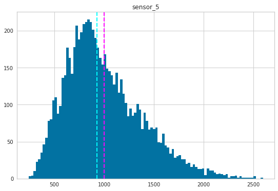

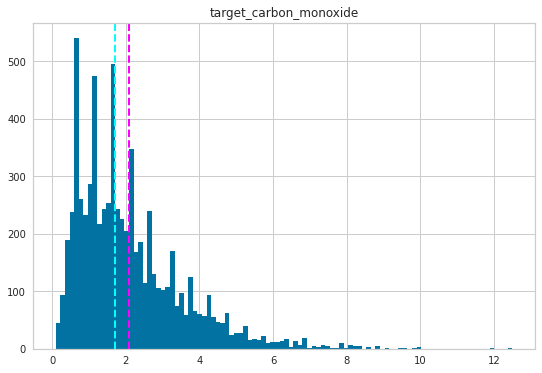

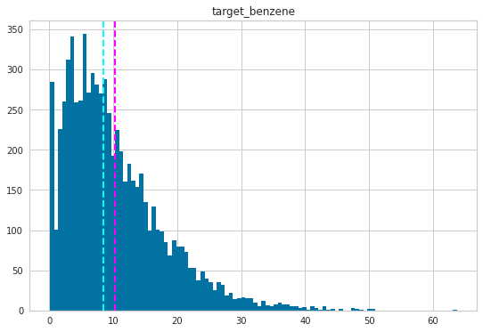

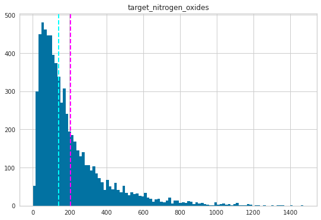

```python
%matplotlib inline

numeric_features = ['deg_C','relative_humidity','absolute_humidity','sensor_1','sensor_2','sensor_3',
                   'sensor_4','sensor_5','target_carbon_monoxide','target_benzene','target_nitrogen_oxides']

'''
Non engineered numerical distribution
'''

for col in numeric_features:        #iterating through the numerical features and plotting the histogram, mean and median
    fig = plt.figure(figsize=(9, 6))
    ax = fig.gca()
    feature = train_eng[col]
    feature.hist(bins=100, ax = ax)
    ax.axvline(feature.mean(), color='magenta', linestyle='dashed', linewidth=2)
    ax.axvline(feature.median(), color='cyan', linestyle='dashed', linewidth=2)
    ax.set_title(col)
plt.show()
```

1. min_max_scaling
2. log_scaling
3. Standard_scaling

```python
'''
applying min_max scaling to the predictors and targets
'''
def min_max_scaling(df):
    df_norm = df.copy()
    for column in df_norm.columns:
        df_norm[column] = (df_norm[column] - df_norm[column].min()) / (df_norm[column].max() - df_norm[column].min())

    return df_norm

eng_norm = min_max_scaling(train_eng)
```

```python
eng_norm.describe()
```

|  | deg_C | relative_humidity | absolute_humidity | sensor_1 | sensor_2 | sensor_3 | sensor_4 | sensor_5 | target_carbon_monoxide | target_benzene | ... | evening | midnight | Friday | Monday | Saturday | Sunday | Thursday | Tuesday | Wednesday | is_weekend |
| --- | --- | --- | --- | --- | --- | --- | --- | --- | --- | --- | --- | --- | --- | --- | --- | --- | --- | --- | --- | --- | --- |
| count | 7111.000000 | 7111.000000 | 7111.000000 | 7111.000000 | 7111.000000 | 7111.000000 | 7111.000000 | 7111.000000 | 7111.000000 | 7111.000000 | ... | 7111.000000 | 7111.000000 | 7111.000000 | 7111.000000 | 7111.000000 | 7111.000000 | 7111.000000 | 7111.000000 | 7111.000000 | 7111.000000 |
| mean | 0.437010 | 0.472051 | 0.448533 | 0.321030 | 0.296123 | 0.254034 | 0.406768 | 0.321287 | 0.160179 | 0.159388 | ... | 0.167065 | 0.166924 | 0.145127 | 0.141752 | 0.141893 | 0.141752 | 0.145127 | 0.141752 | 0.142596 | 0.283645 |
| std | 0.177186 | 0.212439 | 0.196314 | 0.148868 | 0.145455 | 0.137565 | 0.148325 | 0.162225 | 0.116702 | 0.120982 | ... | 0.373060 | 0.372935 | 0.352254 | 0.348820 | 0.348965 | 0.348820 | 0.352254 | 0.348820 | 0.349685 | 0.450798 |
| min | 0.000000 | 0.000000 | 0.000000 | 0.000000 | 0.000000 | 0.000000 | 0.000000 | 0.000000 | 0.000000 | 0.000000 | ... | 0.000000 | 0.000000 | 0.000000 | 0.000000 | 0.000000 | 0.000000 | 0.000000 | 0.000000 | 0.000000 | 0.000000 |
| 25% | 0.303571 | 0.302808 | 0.323344 | 0.211138 | 0.191324 | 0.164148 | 0.325067 | 0.204154 | 0.072581 | 0.069182 | ... | 0.000000 | 0.000000 | 0.000000 | 0.000000 | 0.000000 | 0.000000 | 0.000000 | 0.000000 | 0.000000 | 0.000000 |
| 50% | 0.433036 | 0.468864 | 0.435341 | 0.299864 | 0.283813 | 0.229174 | 0.406709 | 0.291679 | 0.129032 | 0.132075 | ... | 0.000000 | 0.000000 | 0.000000 | 0.000000 | 0.000000 | 0.000000 | 0.000000 | 0.000000 | 0.000000 | 0.000000 |
| 75% | 0.546875 | 0.633700 | 0.593126 | 0.405654 | 0.392087 | 0.309398 | 0.494515 | 0.417535 | 0.217742 | 0.221698 | ... | 0.000000 | 0.000000 | 0.000000 | 0.000000 | 0.000000 | 0.000000 | 0.000000 | 0.000000 | 0.000000 | 1.000000 |
| max | 1.000000 | 1.000000 | 1.000000 | 1.000000 | 1.000000 | 1.000000 | 1.000000 | 1.000000 | 1.000000 | 1.000000 | ... | 1.000000 | 1.000000 | 1.000000 | 1.000000 | 1.000000 | 1.000000 | 1.000000 | 1.000000 | 1.000000 | 1.000000 |

8 rows × 25 columns

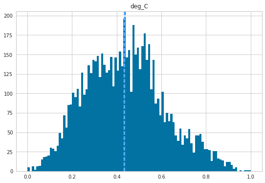

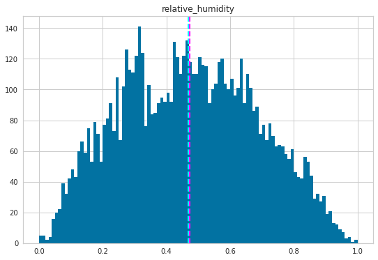

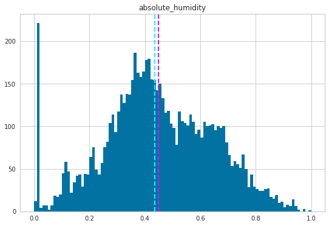

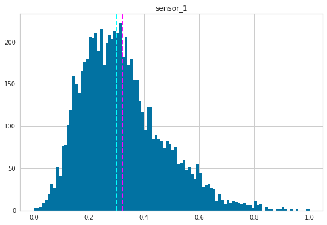

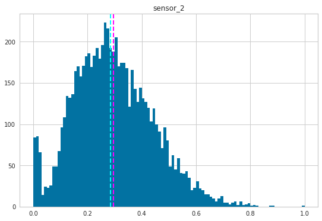

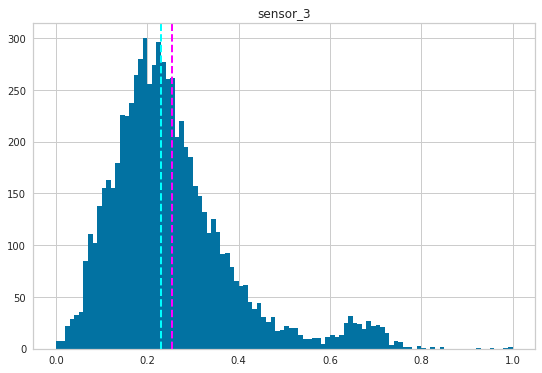

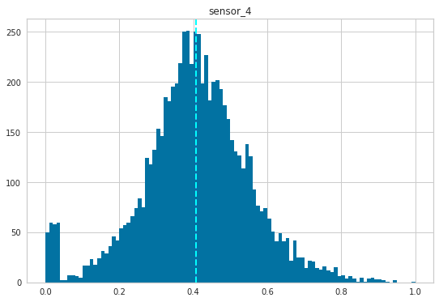

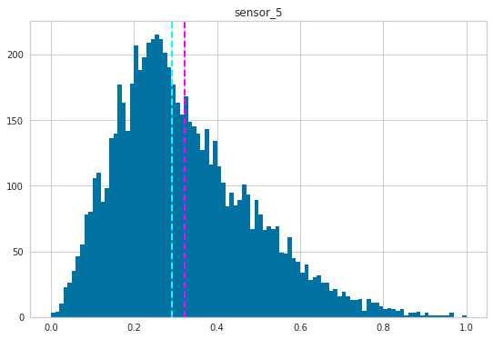

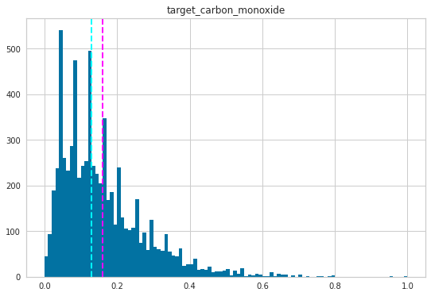

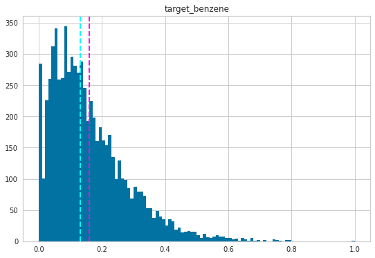

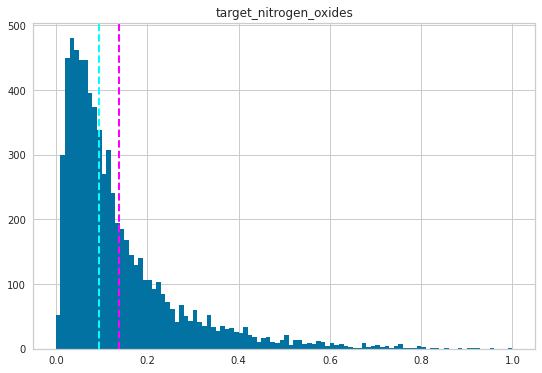

```python
for col in numeric_features:
    fig = plt.figure(figsize=(9, 6))
    ax = fig.gca()
    feature = eng_norm[col]
    feature.hist(bins=100, ax = ax)
    ax.axvline(feature.mean(), color='magenta', linestyle='dashed', linewidth=2)
    ax.axvline(feature.median(), color='cyan', linestyle='dashed', linewidth=2)
    ax.set_title(col)
plt.show()
```